# Lab 06

Elyse McCormick

2022-10-23

**Q1 (3 pts.): Show the R code you used to define your sse_mean() function. Include the following line before your function definition:**

```r
rm(list = ls())

require(palmerpenguins)
sse_mean = function(x) sd(x[!is.na(x)])/ sqrt(length(x[!is.na(x)]))

sse_mean(penguins$body_mass_g)
```

```
## [1] 43.36473
```

```r
sse_mean(mtcars$mpg)
```

```
## [1] 1.065424
```

**Q2 (4 pts.): Show the code you used to define your two_group_resample_diff() function.**

```r
dat_pen = subset(penguins, species != "Gentoo")
x = dat_pen$flipper_length_mm
n_1 = 68
n_2 = 152

dat_1 = sample(x, n_1, replace = TRUE)
dat_2 = sample(x, n_2, replace = TRUE)

diff_simulated =
  mean(dat_1, na.rm = TRUE) - mean(dat_2, na.rm = TRUE)

print(diff_simulated)
```

```
## [1] -2.893748
```

```r
two_group_resample_diff <- function(x, n_1, n_2)
{dat_1 = sample(x[!is.na(x)], n_1, replace = TRUE)
 dat_2 = sample(x[!is.na(x)], n_2, replace = TRUE)
 diff_simulated =
  mean(dat_1, na.rm = TRUE) - mean(dat_2, na.rm = TRUE)
   return(diff_simulated)}

set.seed(54321)
two_group_resample_diff(dat_pen$flipper_length_mm, 68, 152)
```

```
## [1] -1.426471
```

**Q3 (2 pts.): Does your function perform Monte Carlo or bootstrap resampling, i.e. does it simulate a null or an alternative hypothesis? You may want to review your answer after you complete the rest of the lab questions.**

**Q4 (1 pt.): Create a histogram of the resampled differences of means.**

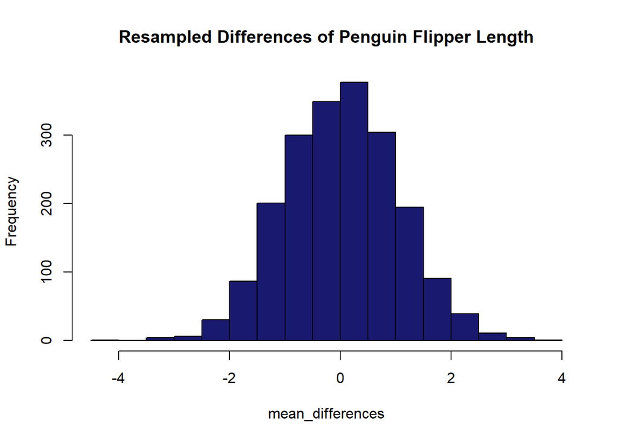

```r
n = 2000
mean_differences = c()
for (i in 1:n)
{
  mean_differences = c(
    mean_differences,
    two_group_resample_diff(dat_pen$flipper_length_mm, 68, 152)
  )
}
hist(mean_differences, main = "Resampled Differences of Penguin Flipper Length", col = "midnightblue")
```

**Q5 (2 pts.): How many of your resampled differences of means had a magnitude greater than 5.8? Assume that we are doing a 2-sided test: we don’t care which species has longer flippers, we only want to know if they are different. Include the R code you used to check the number of differences greater than 5.8.**

```r
sum(abs(mean_differences) > 5.8)
```

```
## [1] 0
```

**Q6 (2 pts.): Given a p value of less than 1 per 10 million, how many simulations do you think you would have to do to see a difference in mean flipper length equal to or greater than 5.8 mm?**

You would have to run more than 10 million tests to see differences, the p value is showing that you would have a 1 in 10 million likelihood of seeing that difference. So to get more than 1 in 10 million, you would have to run multiples of 10 million to see the differences.

**Q7 (1 pt.): Include a boxplot of your chosen variable in your report.**

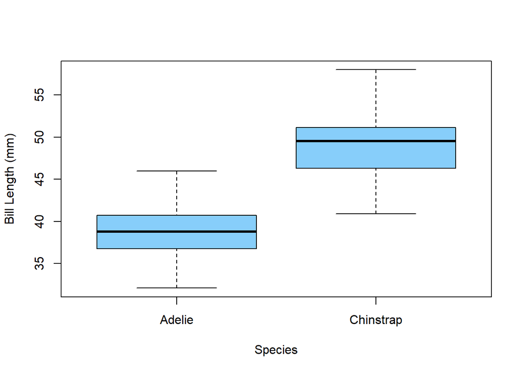

```r
dat_pen = droplevels(subset(penguins, species != "Gentoo"))
boxplot(
  bill_length_mm ~ species, data = dat_pen,
  xlab = "Species",
  ylab = "Bill Length (mm)",
  col = "lightskyblue")
```

**Q8 (3 pts.): Report the group means and difference between the means.**

```r
t.test(dat_pen$bill_length_mm ~ dat_pen$species)
```

```
##
##  Welch Two Sample t-test
##
## data:  dat_pen$bill_length_mm by dat_pen$species
## t = -21.865, df = 106.97, p-value < 2.2e-16
## alternative hypothesis: true difference in means between group Adelie and group Chinstrap is not equal to 0
## 95 percent confidence interval:
##  -10.952948  -9.131917
## sample estimates:
##    mean in group Adelie mean in group Chinstrap
##                38.79139                48.83382
```

```r
t_test = t.test(dat_pen$bill_length_mm ~ dat_pen$species)

t_test$estimate
```

```
##    mean in group Adelie mean in group Chinstrap
##                38.79139                48.83382
```

```r
diff_observed = round(diff(t_test$estimate), digits = 3)
print(diff_observed, digits = 3)
```

```
## mean in group Chinstrap
##                      10
```

Adelie means: 38.79 Chinstrap means: 48.83 Difference between the means: 10

**Q9 (4 pts.): Interpret the p-value from the t-test output in plain, non-technical English that a non-statistician would understand.**

p < 2.2e-16

This p value indicates that there is a detectable difference in bill length between Adelie and Chinstrap penguins. Based on the p value and the average lengths, chinstrap penguins have longer bills than Adelie penguins.

**Q10 (2 pts.): How many differences in means were greater than diff_crit? Remember to treat this as a 2-tailed test.**

```r
agg_means = aggregate(
  bill_length_mm ~ species,
  data = dat_pen,
  FUN = "mean",
  na.rm = TRUE)
diff_crit = diff(agg_means[, 2])

agg_means
```

```
##     species bill_length_mm
## 1    Adelie       38.79139
## 2 Chinstrap       48.83382
```

```r
diff_crit
```

```
## [1] 10.04243
```

```r
#Using the two_group_resample_diff function
set.seed(54321)
two_group_resample_diff(dat_pen$bill_length_mm, 38.79, 48.83)
```

```
## [1] 1.23114
```

**Q11 (1 pt.): Include a histogram of your simulation results in your report. Make sure it has appropriate title and labels.**

#Resampling with a histogram and mean differences

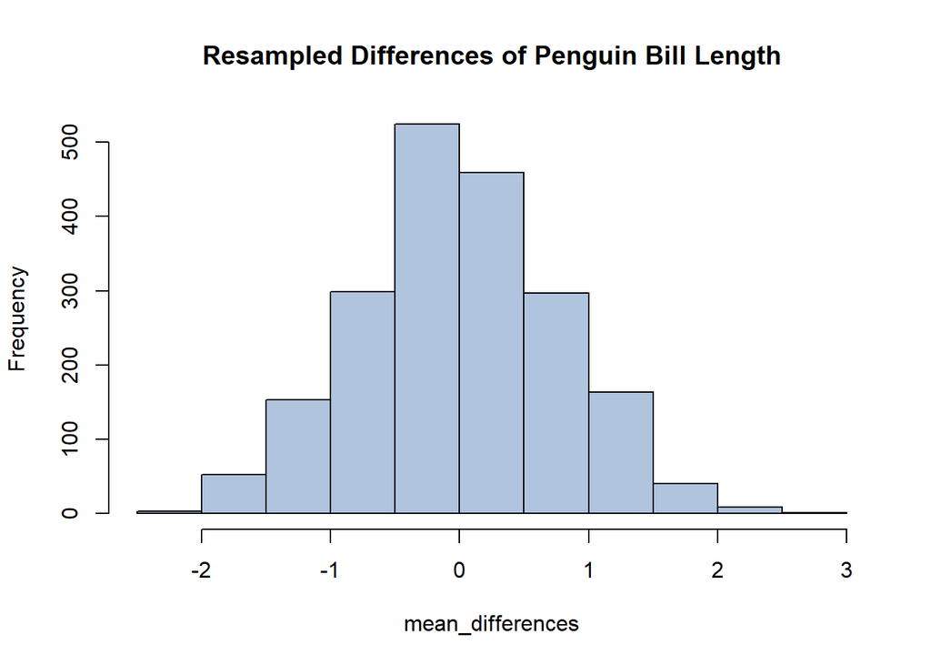

```r
n = 2000
mean_differences = c()
for (i in 1:n)
{
  mean_differences = c(
    mean_differences,
    two_group_resample_diff(dat_pen$bill_length_mm, 68, 152)
  )
}
hist(mean_differences, main = "Resampled Differences of Penguin Bill Length", col = "lightsteelblue")
```

```r
sum(abs(mean_differences) > 1.2)
```

```
## [1] 249
```